# **How Can a Wellness Technology Company Play It Smart?** Bellabeat Case Study

Ifejianyi Grace Amarachi

2022-09-12

## 1. Summary

Bellabeat is the go-to wellness brand for women with an ecosystem of products and services focused on women’s health. They develop smart devices that monitor biometric and lifestyle data such as daily activity, steps, calories, sleep, stress, and reproductive health to help women better understand how their bodies work and make healthier choices.

The Bellabeat app provides users with health data related to their activity, sleep, stress, menstrual cycle, and mindfulness habits. This data can help users better understand their current habits and make healthy decisions.

## 2. Ask

### 2.1. Business Task

The objective of this analysis is to focus on one of Bellabeat’s products and analyze how Non-Bellabeat consumers are using the smart devices.

With the information we are to provide high-level recommendations for how these insights inform Bellabeat’s marketing strategy.

## 3. Prepare phase

### 3.1. Data Used

The data used for the case study is [Fitbit Fitness Tracker Data](https://www.kaggle.com/arashnic/fitbit) (CC0: Public Domain). It was made available through [Mobius](https://www.kaggle.com/arashnic).

### 3.2.Data Privacy and Assecibility

The metadata of the dataset used is confirmed open source.The owner has dedicated the work to Public Domain, there by waiving all of his or her rights to the work worldwide under copyright law, including all related and neighboring rights. The datesets can copied, modified, distributed even for commercial purposes, all without asking permission.

### 3.3. About the Data

This dataset generated by respondents to a distributed survey via Amazon Mechanical Turk between 03.12.2016-05.12.2016. Thirty eligible Fitbit users consented to the submission of personal tracker data, including minute-level output for physical activity, heart rate, and sleep monitoring. Individual reports can be parsed by export session ID (column A) or timestamp (column B). Variation between output represents use of different types of Fitbit trackers and individual tracking behaviors / preferences

### 3.4. Data Organization and Verification

The dataset has 18 CSV documents. Each document represents different quantitative data tracked by Fitbit. 15 in long format, 3 in wide format. The dataset consists of wide-ranging information from activity metrics, calories, sleep records, steps, weight.

Several data frames are subsets of larger, more complete data frames, therefore they will not be used.

### 3.5. Data Credibility and Integrity

1. The dataset was generated in 2016 thus not current.
2. Small sample size
3. Lack of metadata and demographic information of users age, location, gender there is high chance that the data isn`t representative of the population as a whole.
4. The dataset also only contains data within one month of activity, this period is short and might not be enough to show users activity patterns that could be affected by seasons and weather.

## 4. Process

For easy documentation and reproducibility, Data cleaning,analysis and visualizationn will be done in R programming with RStudio.

### 4.1. Setting up my environment

These packages will help in the analysis process in R: `tidyverse`, `ggplot2`, `skimr`, `dplyr`, `lubridate`, `janitor`, `ggpubr`.

### 4.3. Preview Dataframes

Lets have a glimpse of the data we will be working with

```r
head(daily_activity,3)
```

```
## # A tibble: 3 × 15
##       Id Activ…¹ Total…² Total…³ Track…⁴ Logge…⁵ VeryA…⁶ Moder…⁷ Light…⁸ Seden…⁹
##    <dbl> <chr>     <dbl>   <dbl>   <dbl>   <dbl>   <dbl>   <dbl>   <dbl>   <dbl>
## 1 1.50e9 4/12/2…   13162    8.5     8.5        0    1.88   0.550    6.06       0
## 2 1.50e9 4/13/2…   10735    6.97    6.97       0    1.57   0.690    4.71       0
## 3 1.50e9 4/14/2…   10460    6.74    6.74       0    2.44   0.400    3.91       0
## # … with 5 more variables: VeryActiveMinutes <dbl>, FairlyActiveMinutes <dbl>,
## #   LightlyActiveMinutes <dbl>, SedentaryMinutes <dbl>, Calories <dbl>, and
## #   abbreviated variable names ¹ActivityDate, ²TotalSteps, ³TotalDistance,
## #   ⁴TrackerDistance, ⁵LoggedActivitiesDistance, ⁶VeryActiveDistance,
## #   ⁷ModeratelyActiveDistance, ⁸LightActiveDistance, ⁹SedentaryActiveDistance
## # ℹ Use `colnames()` to see all variable names
```

```r
head(hourly_calories,3)
```

```
## # A tibble: 3 × 3
##           Id ActivityHour          Calories
##        <dbl> <chr>                    <dbl>
## 1 1503960366 4/12/2016 12:00:00 AM       81
## 2 1503960366 4/12/2016 1:00:00 AM        61
## 3 1503960366 4/12/2016 2:00:00 AM        59
```

```r
head(hourly_intensities,3)
```

```
## # A tibble: 3 × 4
##           Id ActivityHour          TotalIntensity AverageIntensity
##        <dbl> <chr>                          <dbl>            <dbl>
## 1 1503960366 4/12/2016 12:00:00 AM             20            0.333
## 2 1503960366 4/12/2016 1:00:00 AM               8            0.133
## 3 1503960366 4/12/2016 2:00:00 AM               7            0.117
```

```r
head(hourly_steps,3)
```

```
## # A tibble: 3 × 3
##           Id ActivityHour          StepTotal
##        <dbl> <chr>                     <dbl>
## 1 1503960366 4/12/2016 12:00:00 AM       373
## 2 1503960366 4/12/2016 1:00:00 AM        160
## 3 1503960366 4/12/2016 2:00:00 AM        151
```

```r
head(sleep_day,3)
```

```
## # A tibble: 3 × 5
##           Id SleepDay              TotalSleepRecords TotalMinutesAsleep TotalT…¹
##        <dbl> <chr>                             <dbl>              <dbl>    <dbl>
## 1 1503960366 4/12/2016 12:00:00 AM                 1                327      346
## 2 1503960366 4/13/2016 12:00:00 AM                 2                384      407
## 3 1503960366 4/15/2016 12:00:00 AM                 1                412      442
## # … with abbreviated variable name ¹TotalTimeInBed
```

```r
str(daily_activity)
```

```
## spec_tbl_df [940 × 15] (S3: spec_tbl_df/tbl_df/tbl/data.frame)
##  $ Id                      : num [1:940] 1.5e+09 1.5e+09 1.5e+09 1.5e+09 1.5e+09 ...
##  $ ActivityDate            : chr [1:940] "4/12/2016" "4/13/2016" "4/14/2016" "4/15/2016" ...
##  $ TotalSteps              : num [1:940] 13162 10735 10460 9762 12669 ...
##  $ TotalDistance           : num [1:940] 8.5 6.97 6.74 6.28 8.16 ...
##  $ TrackerDistance         : num [1:940] 8.5 6.97 6.74 6.28 8.16 ...
##  $ LoggedActivitiesDistance: num [1:940] 0 0 0 0 0 0 0 0 0 0 ...
##  $ VeryActiveDistance      : num [1:940] 1.88 1.57 2.44 2.14 2.71 ...
##  $ ModeratelyActiveDistance: num [1:940] 0.55 0.69 0.4 1.26 0.41 ...
##  $ LightActiveDistance     : num [1:940] 6.06 4.71 3.91 2.83 5.04 ...
##  $ SedentaryActiveDistance : num [1:940] 0 0 0 0 0 0 0 0 0 0 ...
##  $ VeryActiveMinutes       : num [1:940] 25 21 30 29 36 38 42 50 28 19 ...
##  $ FairlyActiveMinutes     : num [1:940] 13 19 11 34 10 20 16 31 12 8 ...
##  $ LightlyActiveMinutes    : num [1:940] 328 217 181 209 221 164 233 264 205 211 ...
##  $ SedentaryMinutes        : num [1:940] 728 776 1218 726 773 ...
##  $ Calories                : num [1:940] 1985 1797 1776 1745 1863 ...
##  - attr(*, "spec")=
##   .. cols(
##   ..   Id = col_double(),
##   ..   ActivityDate = col_character(),
##   ..   TotalSteps = col_double(),
##   ..   TotalDistance = col_double(),
##   ..   TrackerDistance = col_double(),
##   ..   LoggedActivitiesDistance = col_double(),
##   ..   VeryActiveDistance = col_double(),
##   ..   ModeratelyActiveDistance = col_double(),
##   ..   LightActiveDistance = col_double(),
##   ..   SedentaryActiveDistance = col_double(),
##   ..   VeryActiveMinutes = col_double(),
##   ..   FairlyActiveMinutes = col_double(),
##   ..   LightlyActiveMinutes = col_double(),
##   ..   SedentaryMinutes = col_double(),
##   ..   Calories = col_double()
##   .. )
##  - attr(*, "problems")=<externalptr>
```

```r
str(hourly_calories)
```

```
## spec_tbl_df [22,099 × 3] (S3: spec_tbl_df/tbl_df/tbl/data.frame)
##  $ Id          : num [1:22099] 1.5e+09 1.5e+09 1.5e+09 1.5e+09 1.5e+09 ...
##  $ ActivityHour: chr [1:22099] "4/12/2016 12:00:00 AM" "4/12/2016 1:00:00 AM" "4/12/2016 2:00:00 AM" "4/12/2016 3:00:00 AM" ...
##  $ Calories    : num [1:22099] 81 61 59 47 48 48 48 47 68 141 ...
##  - attr(*, "spec")=
##   .. cols(
##   ..   Id = col_double(),
##   ..   ActivityHour = col_character(),
##   ..   Calories = col_double()
##   .. )
##  - attr(*, "problems")=<externalptr>
```

```r
str(hourly_intensities)
```

```
## spec_tbl_df [22,099 × 4] (S3: spec_tbl_df/tbl_df/tbl/data.frame)
##  $ Id              : num [1:22099] 1.5e+09 1.5e+09 1.5e+09 1.5e+09 1.5e+09 ...
##  $ ActivityHour    : chr [1:22099] "4/12/2016 12:00:00 AM" "4/12/2016 1:00:00 AM" "4/12/2016 2:00:00 AM" "4/12/2016 3:00:00 AM" ...
##  $ TotalIntensity  : num [1:22099] 20 8 7 0 0 0 0 0 13 30 ...
##  $ AverageIntensity: num [1:22099] 0.333 0.133 0.117 0 0 ...
##  - attr(*, "spec")=
##   .. cols(
##   ..   Id = col_double(),
##   ..   ActivityHour = col_character(),
##   ..   TotalIntensity = col_double(),
##   ..   AverageIntensity = col_double()
##   .. )
##  - attr(*, "problems")=<externalptr>
```

```r
str(hourly_steps)
```

```
## spec_tbl_df [22,099 × 3] (S3: spec_tbl_df/tbl_df/tbl/data.frame)
##  $ Id          : num [1:22099] 1.5e+09 1.5e+09 1.5e+09 1.5e+09 1.5e+09 ...
##  $ ActivityHour: chr [1:22099] "4/12/2016 12:00:00 AM" "4/12/2016 1:00:00 AM" "4/12/2016 2:00:00 AM" "4/12/2016 3:00:00 AM" ...
##  $ StepTotal   : num [1:22099] 373 160 151 0 0 ...
##  - attr(*, "spec")=
##   .. cols(
##   ..   Id = col_double(),
##   ..   ActivityHour = col_character(),
##   ..   StepTotal = col_double()
##   .. )
##  - attr(*, "problems")=<externalptr>
```

```r
str(sleep_day)
```

```
## spec_tbl_df [413 × 5] (S3: spec_tbl_df/tbl_df/tbl/data.frame)
##  $ Id                : num [1:413] 1.5e+09 1.5e+09 1.5e+09 1.5e+09 1.5e+09 ...
##  $ SleepDay          : chr [1:413] "4/12/2016 12:00:00 AM" "4/13/2016 12:00:00 AM" "4/15/2016 12:00:00 AM" "4/16/2016 12:00:00 AM" ...
##  $ TotalSleepRecords : num [1:413] 1 2 1 2 1 1 1 1 1 1 ...
##  $ TotalMinutesAsleep: num [1:413] 327 384 412 340 700 304 360 325 361 430 ...
##  $ TotalTimeInBed    : num [1:413] 346 407 442 367 712 320 377 364 384 449 ...
##  - attr(*, "spec")=
##   .. cols(
##   ..   Id = col_double(),
##   ..   SleepDay = col_character(),
##   ..   TotalSleepRecords = col_double(),
##   ..   TotalMinutesAsleep = col_double(),
##   ..   TotalTimeInBed = col_double()
##   .. )
##  - attr(*, "problems")=<externalptr>
```

### 4.4. Cleaning and Formatting

```r
hourly_calories <- clean_names(hourly_calories)
hourly_intensities <- clean_names(hourly_intensities)
daily_activity <- clean_names(daily_activity)
daily_sleep <-clean_names(sleep_day)
hourly_steps <- clean_names(hourly_steps)
```

```r
colnames(daily_activity)
```

```
##  [1] "id"                         "activity_date"
##  [3] "total_steps"                "total_distance"
##  [5] "tracker_distance"           "logged_activities_distance"
##  [7] "very_active_distance"       "moderately_active_distance"
##  [9] "light_active_distance"      "sedentary_active_distance"
## [11] "very_active_minutes"        "fairly_active_minutes"
## [13] "lightly_active_minutes"     "sedentary_minutes"
## [15] "calories"
```

```r
colnames(hourly_calories)
```

```
## [1] "id"            "activity_hour" "calories"
```

```r
colnames(hourly_intensities)
```

```
## [1] "id"                "activity_hour"     "total_intensity"
## [4] "average_intensity"
```

```r
colnames(hourly_steps)
```

```
## [1] "id"            "activity_hour" "step_total"
```

```r
colnames(daily_sleep)
```

```
## [1] "id"                   "sleep_day"            "total_sleep_records"
## [4] "total_minutes_asleep" "total_time_in_bed"
```

```r
sum(duplicated(hourly_calories))
```

```
## [1] 0
```

```r
sum(duplicated(hourly_steps))
```

```
## [1] 0
```

```r
sum(duplicated(hourly_intensities))
```

```
## [1] 0
```

```r
sum(duplicated(daily_sleep))
```

```
## [1] 3
```

```r
sum(duplicated(daily_activity))
```

```
## [1] 0
```

#### 4.4.3. Remove duplcates and N/A

```r
hourly_calories <- hourly_calories %>%
  distinct() %>%
  drop_na()

hourly_steps <- hourly_steps %>%
  distinct() %>%
  drop_na()

hourly_intensities <- hourly_intensities %>%
  distinct() %>%
  drop_na()

daily_activity <- daily_activity %>%
  distinct() %>%
  drop_na()

daily_sleep <- daily_sleep %>%
  distinct() %>%
  drop_na()
```

#### 4.4.4 Verify duplicates and N/A

```r
sum(duplicated(hourly_calories))
```

```
## [1] 0
```

```r
sum(duplicated(hourly_steps))
```

```
## [1] 0
```

```r
sum(duplicated(hourly_intensities))
```

```
## [1] 0
```

```r
sum(duplicated(daily_sleep))
```

```
## [1] 0
```

```r
sum(duplicated(daily_activity))
```

```
## [1] 0
```

```r
sum(is.na(hourly_calories))
```

```
## [1] 0
```

```r
sum(is.na(hourly_steps))
```

```
## [1] 0
```

```r
sum(is.na(hourly_intensities))
```

```
## [1] 0
```

```r
sum(is.na(daily_sleep))
```

```
## [1] 0
```

```r
sum(is.na(daily_activity))
```

```
## [1] 0
```

```r
head(daily_activity,3)
```

```
## # A tibble: 3 × 15
##       id activ…¹ total…² total…³ track…⁴ logge…⁵ very_…⁶ moder…⁷ light…⁸ seden…⁹
##    <dbl> <chr>     <dbl>   <dbl>   <dbl>   <dbl>   <dbl>   <dbl>   <dbl>   <dbl>
## 1 1.50e9 4/12/2…   13162    8.5     8.5        0    1.88   0.550    6.06       0
## 2 1.50e9 4/13/2…   10735    6.97    6.97       0    1.57   0.690    4.71       0
## 3 1.50e9 4/14/2…   10460    6.74    6.74       0    2.44   0.400    3.91       0
## # … with 5 more variables: very_active_minutes <dbl>,
## #   fairly_active_minutes <dbl>, lightly_active_minutes <dbl>,
## #   sedentary_minutes <dbl>, calories <dbl>, and abbreviated variable names
## #   ¹activity_date, ²total_steps, ³total_distance, ⁴tracker_distance,
## #   ⁵logged_activities_distance, ⁶very_active_distance,
## #   ⁷moderately_active_distance, ⁸light_active_distance,
## #   ⁹sedentary_active_distance
## # ℹ Use `colnames()` to see all variable names
```

```r
head(hourly_calories,3)
```

```
## # A tibble: 3 × 3
##           id activity_hour         calories
##        <dbl> <chr>                    <dbl>
## 1 1503960366 4/12/2016 12:00:00 AM       81
## 2 1503960366 4/12/2016 1:00:00 AM        61
## 3 1503960366 4/12/2016 2:00:00 AM        59
```

```r
head(hourly_intensities,3)
```

```
## # A tibble: 3 × 4
##           id activity_hour         total_intensity average_intensity
##        <dbl> <chr>                           <dbl>             <dbl>
## 1 1503960366 4/12/2016 12:00:00 AM              20             0.333
## 2 1503960366 4/12/2016 1:00:00 AM                8             0.133
## 3 1503960366 4/12/2016 2:00:00 AM                7             0.117
```

```r
head(hourly_steps,3)
```

```
## # A tibble: 3 × 3
##           id activity_hour         step_total
##        <dbl> <chr>                      <dbl>
## 1 1503960366 4/12/2016 12:00:00 AM        373
## 2 1503960366 4/12/2016 1:00:00 AM         160
## 3 1503960366 4/12/2016 2:00:00 AM         151
```

```r
head(daily_sleep,3)
```

```
## # A tibble: 3 × 5
##           id sleep_day             total_sleep_records total_minutes_a…¹ total…²
##        <dbl> <chr>                               <dbl>             <dbl>   <dbl>
## 1 1503960366 4/12/2016 12:00:00 AM                   1               327     346
## 2 1503960366 4/13/2016 12:00:00 AM                   2               384     407
## 3 1503960366 4/15/2016 12:00:00 AM                   1               412     442
## # … with abbreviated variable names ¹total_minutes_asleep, ²total_time_in_bed
```

#### 4.4.5. Formatting Date and Time columns

Earlier we obverved that `sleep_date` is in a character format `<chr>`,we need change it into `POSIXct` formats. This is important for an hour by hour analysis of our data. We also have to rename the the colomns for easy refers.

```r
# formatting date and time
#rename columns

hourly_calories <- hourly_calories %>%
  rename(date_time = activity_hour)

hourly_steps <- hourly_steps %>%
  rename(date_time = activity_hour)

hourly_intensities <- hourly_intensities %>%
  rename(date_time = activity_hour)

daily_activity <- daily_activity %>%
  rename(date = activity_date)

daily_sleep <- daily_sleep %>%
  rename(date = sleep_day)



head(daily_activity,3)
```

```
## # A tibble: 3 × 15
##         id date  total…¹ total…² track…³ logge…⁴ very_…⁵ moder…⁶ light…⁷ seden…⁸
##      <dbl> <chr>   <dbl>   <dbl>   <dbl>   <dbl>   <dbl>   <dbl>   <dbl>   <dbl>
## 1   1.50e9 4/12…   13162    8.5     8.5        0    1.88   0.550    6.06       0
## 2   1.50e9 4/13…   10735    6.97    6.97       0    1.57   0.690    4.71       0
## 3   1.50e9 4/14…   10460    6.74    6.74       0    2.44   0.400    3.91       0
## # … with 5 more variables: very_active_minutes <dbl>,
## #   fairly_active_minutes <dbl>, lightly_active_minutes <dbl>,
## #   sedentary_minutes <dbl>, calories <dbl>, and abbreviated variable names
## #   ¹total_steps, ²total_distance, ³tracker_distance,
## #   ⁴logged_activities_distance, ⁵very_active_distance,
## #   ⁶moderately_active_distance, ⁷light_active_distance,
## #   ⁸sedentary_active_distance
## # ℹ Use `colnames()` to see all variable names
```

```r
head(hourly_calories,3)
```

```
## # A tibble: 3 × 3
##           id date_time             calories
##        <dbl> <chr>                    <dbl>
## 1 1503960366 4/12/2016 12:00:00 AM       81
## 2 1503960366 4/12/2016 1:00:00 AM        61
## 3 1503960366 4/12/2016 2:00:00 AM        59
```

```r
head(hourly_intensities,3)
```

```
## # A tibble: 3 × 4
##           id date_time             total_intensity average_intensity
##        <dbl> <chr>                           <dbl>             <dbl>
## 1 1503960366 4/12/2016 12:00:00 AM              20             0.333
## 2 1503960366 4/12/2016 1:00:00 AM                8             0.133
## 3 1503960366 4/12/2016 2:00:00 AM                7             0.117
```

```r
head(hourly_steps,3)
```

```
## # A tibble: 3 × 3
##           id date_time             step_total
##        <dbl> <chr>                      <dbl>
## 1 1503960366 4/12/2016 12:00:00 AM        373
## 2 1503960366 4/12/2016 1:00:00 AM         160
## 3 1503960366 4/12/2016 2:00:00 AM         151
```

```r
head(daily_sleep,3)
```

```
## # A tibble: 3 × 5
##           id date                  total_sleep_records total_minutes_a…¹ total…²
##        <dbl> <chr>                               <dbl>             <dbl>   <dbl>
## 1 1503960366 4/12/2016 12:00:00 AM                   1               327     346
## 2 1503960366 4/13/2016 12:00:00 AM                   2               384     407
## 3 1503960366 4/15/2016 12:00:00 AM                   1               412     442
## # … with abbreviated variable names ¹total_minutes_asleep, ²total_time_in_bed
```

```r
hourly_calories<- hourly_calories%>%
  mutate(date_time=as.POSIXct(hourly_calories$date_time, format = "%m/%d/%Y %I:%M:%S %p",tz = Sys.timezone()))

hourly_intensities<- hourly_intensities%>%
  mutate(date_time=as.POSIXct(hourly_calories$date_time, format = "%m/%d/%Y %I:%M:%S %p",tz = Sys.timezone()))

hourly_steps<- hourly_steps%>%
  mutate(date_time=as.POSIXct(hourly_calories$date_time, format = "%m/%d/%Y %I:%M:%S %p",tz = Sys.timezone()))

daily_sleep<-daily_sleep%>%
  mutate(date=as.POSIXct(daily_sleep$date, format = "%m/%d/%Y %I:%M:%S %p",tz = Sys.timezone()))

daily_activity<- daily_activity%>%
  mutate(date=as.POSIXct(daily_activity$date, format = "%m/%d/%Y"))

head(daily_activity,3)
```

```
## # A tibble: 3 × 15
##           id date                total…¹ total…² track…³ logge…⁴ very_…⁵ moder…⁶
##        <dbl> <dttm>                <dbl>   <dbl>   <dbl>   <dbl>   <dbl>   <dbl>
## 1 1503960366 2016-04-12 00:00:00   13162    8.5     8.5        0    1.88   0.550
## 2 1503960366 2016-04-13 00:00:00   10735    6.97    6.97       0    1.57   0.690
## 3 1503960366 2016-04-14 00:00:00   10460    6.74    6.74       0    2.44   0.400
## # … with 7 more variables: light_active_distance <dbl>,
## #   sedentary_active_distance <dbl>, very_active_minutes <dbl>,
## #   fairly_active_minutes <dbl>, lightly_active_minutes <dbl>,
## #   sedentary_minutes <dbl>, calories <dbl>, and abbreviated variable names
## #   ¹total_steps, ²total_distance, ³tracker_distance,
## #   ⁴logged_activities_distance, ⁵very_active_distance,
## #   ⁶moderately_active_distance
## # ℹ Use `colnames()` to see all variable names
```

```r
head(hourly_calories,3)
```

```
## # A tibble: 3 × 3
##           id date_time           calories
##        <dbl> <dttm>                 <dbl>
## 1 1503960366 2016-04-12 00:00:00       81
## 2 1503960366 2016-04-12 01:00:00       61
## 3 1503960366 2016-04-12 02:00:00       59
```

```r
head(hourly_intensities,3)
```

```
## # A tibble: 3 × 4
##           id date_time           total_intensity average_intensity
##        <dbl> <dttm>                        <dbl>             <dbl>
## 1 1503960366 2016-04-12 00:00:00              20             0.333
## 2 1503960366 2016-04-12 01:00:00               8             0.133
## 3 1503960366 2016-04-12 02:00:00               7             0.117
```

```r
head(hourly_steps,3)
```

```
## # A tibble: 3 × 3
##           id date_time           step_total
##        <dbl> <dttm>                   <dbl>
## 1 1503960366 2016-04-12 00:00:00        373
## 2 1503960366 2016-04-12 01:00:00        160
## 3 1503960366 2016-04-12 02:00:00        151
```

```r
head(daily_sleep,3)
```

```
## # A tibble: 3 × 5
##           id date                total_sleep_records total_minutes_asl…¹ total…²
##        <dbl> <dttm>                            <dbl>               <dbl>   <dbl>
## 1 1503960366 2016-04-12 00:00:00                   1                 327     346
## 2 1503960366 2016-04-13 00:00:00                   2                 384     407
## 3 1503960366 2016-04-15 00:00:00                   1                 412     442
## # … with abbreviated variable names ¹total_minutes_asleep, ²total_time_in_bed
```

### 4.5. Merging Data

```r
daily_activity_sleep <- inner_join(daily_activity, daily_sleep, by= "id")

head(daily_activity_sleep,3)
```

```
## # A tibble: 3 × 19
##           id date.x              total…¹ total…² track…³ logge…⁴ very_…⁵ moder…⁶
##        <dbl> <dttm>                <dbl>   <dbl>   <dbl>   <dbl>   <dbl>   <dbl>
## 1 1503960366 2016-04-12 00:00:00   13162     8.5     8.5       0    1.88   0.550
## 2 1503960366 2016-04-12 00:00:00   13162     8.5     8.5       0    1.88   0.550
## 3 1503960366 2016-04-12 00:00:00   13162     8.5     8.5       0    1.88   0.550
## # … with 11 more variables: light_active_distance <dbl>,
## #   sedentary_active_distance <dbl>, very_active_minutes <dbl>,
## #   fairly_active_minutes <dbl>, lightly_active_minutes <dbl>,
## #   sedentary_minutes <dbl>, calories <dbl>, date.y <dttm>,
## #   total_sleep_records <dbl>, total_minutes_asleep <dbl>,
## #   total_time_in_bed <dbl>, and abbreviated variable names ¹total_steps,
## #   ²total_distance, ³tracker_distance, ⁴logged_activities_distance, …
## # ℹ Use `colnames()` to see all variable names
```

```r
n_distinct(daily_activity_sleep$id)
```

```
## [1] 24
```

## 5. Analyse

The data has stored appropriately and has been prepared for analysis, let’s analyse trends

### 5.1. Category of users

Classification of users based on daily average steps: users were categorized according to [National center for biotechnology information](https://www.ncbi.nlm.nih.gov/pmc/articles/PMC5488109/) into five categories;

- Steps per day Classification
- <5000 Sedentary lifestyle
- 5000–7499 Physically inactive
- 7500–9999 Moderately active
- ≥10,000 Physically active
- ≥12,500 Very active

We will now classify our users by the daily average steps

```r
user_type_by_steps <- daily_activity_sleep   %>%
  group_by(id) %>%
  summarise(average_steps = mean(total_steps)) %>%
  mutate(user_type = case_when(average_steps >= 12500 ~ "Highly Active",
                              average_steps >= 10000 ~ "Active",
                              average_steps >= 7500 ~ "Fairly Active" ,
                              average_steps >= 5000  ~ "Low Active",
                              average_steps < 5000 ~ "Sedentary"),
        user_type = factor(user_type, levels = c("Sedentary", 'Low Active', "Fairly Active", "Active", "Highly Active")))

head(user_type_by_steps,3)
```

```
## # A tibble: 3 × 3
##           id average_steps user_type
##        <dbl>         <dbl> <fct>
## 1 1503960366        12117. Active
## 2 1644430081         7283. Low Active
## 3 1844505072         2580. Sedentary
```

To visualize on a pie chart for user type we create a dataframe with the percentage of each user type

```r
user_type_by_steps_percent<- user_type_by_steps%>%
   group_by(user_type) %>% summarise(users =n())%>%
   mutate(total_users = sum(users))%>%  group_by(user_type)%>%
   summarise(percent =(users/total_users))%>%
   mutate(labels = scales::percent(percent))

head(user_type_by_steps_percent)
```

```
## # A tibble: 5 × 3
##   user_type     percent labels
##   <fct>           <dbl> <chr>
## 1 Sedentary      0.292  29.2%
## 2 Low Active     0.167  16.7%
## 3 Fairly Active  0.333  33.3%
## 4 Active         0.167  16.7%
## 5 Highly Active  0.0417 4.2%
```

Visualize on a pie chart

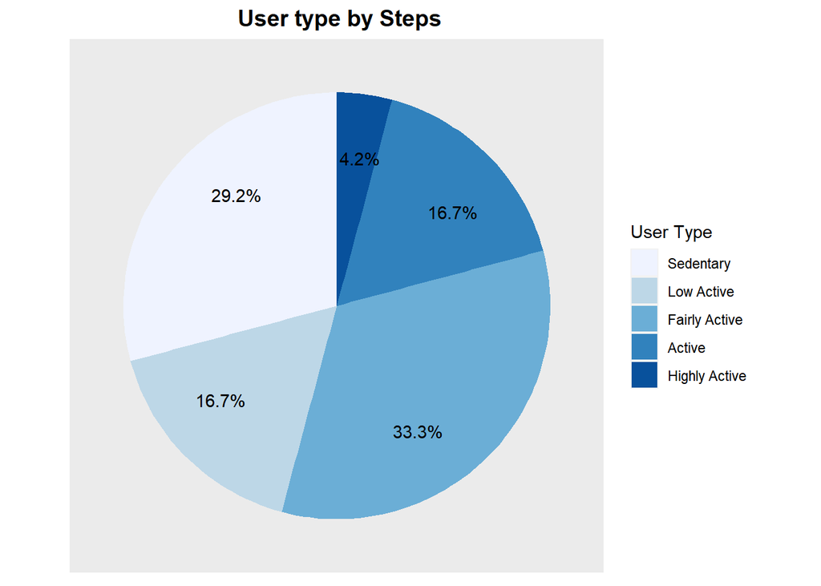

```r
user_type_by_steps_percent%>%
ggplot(aes(x="", y = percent, fill = user_type)) +
  geom_bar(stat = "identity", width = 1) +
  coord_polar("y", start = 0) +
  scale_fill_brewer()+
  theme(  axis.ticks = element_blank(),
          panel.grid = element_blank(),
          axis.text = element_blank(),
          axis.title.x = element_blank(),
          axis.title.y = element_blank(),
          panel.border = element_blank(),
          plot.title = element_text(hjust = 0.5, size=14, face = "bold")) +
  geom_text(aes(label = labels, x= 1.2),
                position = position_stack(vjust = 0.6),
                color = "black") +
  labs(title = " User type by Steps") +
    guides(fill = guide_legend(title = "User Type"))
```

```r
  options(repr.plot.width = 1, repr.plot.height = 1)
```

### 5.2. Daily use of smart device; usage type distribution; how the smart device was used by the participants

```r
  min(daily_activity$total_steps)
```

```
## [1] 0
```

```r
  max(daily_activity$total_steps)
```

```
## [1] 36019
```

```r
  mean(daily_activity$total_steps)
```

```
## [1] 7637.911
```

The average total steps is 7637.91,lets assume that participants didn’t make use of their smart watches on days with the total steps <200 so they are filtered out. We assign the following usage types;

- Low use - 1- 10 days
- moderate use - 11-20 days
- high use 21-31 days

Create a dataframe showing the categories

```r
 daily_usage_group <- daily_activity %>%
    filter(total_steps >200 ) %>%
    group_by(id) %>%
    summarize(date=sum(n())) %>%
    mutate(usage = case_when(
      date >= 1 & date <= 10 ~ "Low Use",
      date >= 11 & date <= 20 ~ "Moderate Use",
      date >= 21 & date <= 31 ~ "High Use")) %>%
    mutate(usage = factor(usage, level = c('High Use','Moderate Use', 'Low Use'))) %>%
    rename(daysused = date) %>%
    group_by(usage)

  head(daily_usage_group,3)
```

```
## # A tibble: 3 × 3
## # Groups:   usage [1]
##           id daysused usage
##        <dbl>    <int> <fct>
## 1 1503960366       30 High Use
## 2 1624580081       31 High Use
## 3 1644430081       30 High Use
```

To visualize on a pie chart for user type, we create a dataframe

```r
daily_usage_group_pc<- daily_usage_group%>%
     group_by(usage) %>%
     summarise(participants =n())%>%
     mutate(total_participants=sum(participants))%>%
    group_by(usage)%>%
     summarise(percent= participants/total_participants)%>%
     arrange(percent)%>%
     mutate(labels = scales::percent(percent))

head(daily_usage_group_pc)
```

```
## # A tibble: 3 × 3
##   usage        percent labels
##   <fct>          <dbl> <chr>
## 1 Low Use       0.0303 3%
## 2 Moderate Use  0.242  24%
## 3 High Use      0.727  73%
```

Visualizing on a pie chart

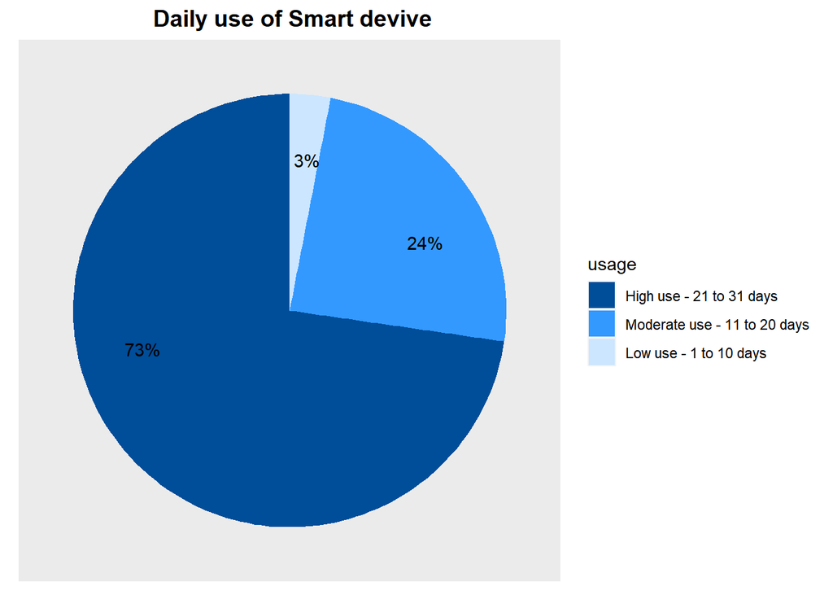

```r
     daily_usage_group_pc%>%
  ggplot(aes(x="", y = percent, fill =usage)) +
  geom_bar(stat = "identity", width = 1) +
  coord_polar("y", start = 0) +
      theme(  axis.ticks = element_blank(),
          panel.grid = element_blank(),
          axis.text = element_blank(),
          axis.title.x = element_blank(),
          axis.title.y = element_blank(),
          panel.border = element_blank(),
          plot.title = element_text(hjust = 0.5, size=14, face = "bold")) +
  geom_text(aes(label = labels, x= 1.2),
            position = position_stack(vjust = 0.6)) +
 scale_fill_manual(values = c("#004d99", "#3399ff", "#cce6ff"),
                  labels = c("High use - 21 to 31 days",
                             "Moderate use - 11 to 20 days",
                             "Low use - 1 to 10 days"))+
      labs(title = " Daily use of Smart devive")
```

### 5.3. Average steps

We will be looking at the average steps by day, by usage groups and steps through the hours of the day.

#### 5.3.1. Average steps by day

Leftjoin daily activity with usage groups df

```r
head(daily_activity)
```

```
## # A tibble: 6 × 15
##           id date                total…¹ total…² track…³ logge…⁴ very_…⁵ moder…⁶
##        <dbl> <dttm>                <dbl>   <dbl>   <dbl>   <dbl>   <dbl>   <dbl>
## 1 1503960366 2016-04-12 00:00:00   13162    8.5     8.5        0    1.88   0.550
## 2 1503960366 2016-04-13 00:00:00   10735    6.97    6.97       0    1.57   0.690
## 3 1503960366 2016-04-14 00:00:00   10460    6.74    6.74       0    2.44   0.400
## 4 1503960366 2016-04-15 00:00:00    9762    6.28    6.28       0    2.14   1.26
## 5 1503960366 2016-04-16 00:00:00   12669    8.16    8.16       0    2.71   0.410
## 6 1503960366 2016-04-17 00:00:00    9705    6.48    6.48       0    3.19   0.780
## # … with 7 more variables: light_active_distance <dbl>,
## #   sedentary_active_distance <dbl>, very_active_minutes <dbl>,
## #   fairly_active_minutes <dbl>, lightly_active_minutes <dbl>,
## #   sedentary_minutes <dbl>, calories <dbl>, and abbreviated variable names
## #   ¹total_steps, ²total_distance, ³tracker_distance,
## #   ⁴logged_activities_distance, ⁵very_active_distance,
## #   ⁶moderately_active_distance
## # ℹ Use `colnames()` to see all variable names
```

```r
daily_activity_usage <- daily_activity%>%
  left_join(daily_usage_group, by= 'id')%>%
  mutate(day= format(ymd(date), format = '%a'))%>%
  mutate(total_mintutes_worn = sedentary_minutes+lightly_active_minutes+fairly_active_minutes+very_active_minutes)%>%
  mutate(total_hours= seconds_to_period(total_mintutes_worn*60))

head(daily_activity_usage,3)
```

```
## # A tibble: 3 × 20
##           id date                total…¹ total…² track…³ logge…⁴ very_…⁵ moder…⁶
##        <dbl> <dttm>                <dbl>   <dbl>   <dbl>   <dbl>   <dbl>   <dbl>
## 1 1503960366 2016-04-12 00:00:00   13162    8.5     8.5        0    1.88   0.550
## 2 1503960366 2016-04-13 00:00:00   10735    6.97    6.97       0    1.57   0.690
## 3 1503960366 2016-04-14 00:00:00   10460    6.74    6.74       0    2.44   0.400
## # … with 12 more variables: light_active_distance <dbl>,
## #   sedentary_active_distance <dbl>, very_active_minutes <dbl>,
## #   fairly_active_minutes <dbl>, lightly_active_minutes <dbl>,
## #   sedentary_minutes <dbl>, calories <dbl>, daysused <int>, usage <fct>,
## #   day <chr>, total_mintutes_worn <dbl>, total_hours <Period>, and abbreviated
## #   variable names ¹total_steps, ²total_distance, ³tracker_distance,
## #   ⁴logged_activities_distance, ⁵very_active_distance, …
## # ℹ Use `colnames()` to see all variable names
```

```r
# average steps per day dataframe

steps_per_day<- daily_activity_usage%>%
  group_by(day)%>%
  summarise(average_steps = round(mean(total_steps)))%>%
  mutate(day= factor(day, levels = c('Mon', 'Tue', 'Wed', 'Thu', 'Fri', 'Sat', 'Sun')))

head(steps_per_day)
```

```
## # A tibble: 6 × 2
##   day   average_steps
##   <fct>         <dbl>
## 1 Fri            7448
## 2 Mon            7781
## 3 Sat            8153
## 4 Sun            6933
## 5 Thu            7406
## 6 Tue            8125
```

[figure not shown]

```r
ggplot(steps_per_day, aes(x=day, y= average_steps, fill= average_steps))+
  geom_col(color="darkblue", size = 0.1) +
  geom_hline(yintercept = 7500)+
  scale_fill_gradientn(limits=c(0,10000), breaks=seq(0,10000, by = 2500),
                       colours = brewer.pal(9, "Blues")) +
  scale_y_continuous(limits=c(0,10000), breaks=seq(0, 10000, by = 2500))+
  labs(title= ("Average Steps"), subtitle = ('By Day'), x="" , y="Calories")+
  theme(plot.title=element_text(size = 16,hjust = 0))+
  theme(plot.subtitle=element_text(size = 14,hjust = 0))+
  theme(axis.text.y=element_text(size=14)) +
  theme(axis.text.x=element_text(size=14,hjust= 0.5))+
  theme(axis.title.x = element_text(margin = margin(t = 14, r = 0, b = 0, l = 0)))+
  theme(axis.title.y = element_text(margin = margin(t = 0, r = 10, b = 0, l = 0)))+
  theme(legend.position = "top")+
  theme(legend.title=element_text(size=12))+
  theme(legend.text=element_text(size=8))+
  guides(fill = guide_colourbar(barwidth = 12))
```

```r
options(repr.plot.width = 10, repr.plot.height = 8)
```

**Observations** * Tuesday and Saturday are recorded the most active days * Sunday has the lowest number of steps, unsurprisingly a rest day

#### 5.3.2. Average steps by usage groups

```r
steps_by_ug<- daily_activity_usage%>%
  group_by(day, usage)%>%
select(usage, total_steps,day)%>%
  mutate(day= factor(day, level=c('Mon', 'Tue', 'Wed', 'Thu', 'Fri', 'Sat', 'Sun')))

head(steps_by_ug,3)
```

```
## # A tibble: 3 × 3
## # Groups:   day, usage [3]
##   usage    total_steps day
##   <fct>          <dbl> <fct>
## 1 High Use       13162 Tue
## 2 High Use       10735 Wed
## 3 High Use       10460 Thu
```

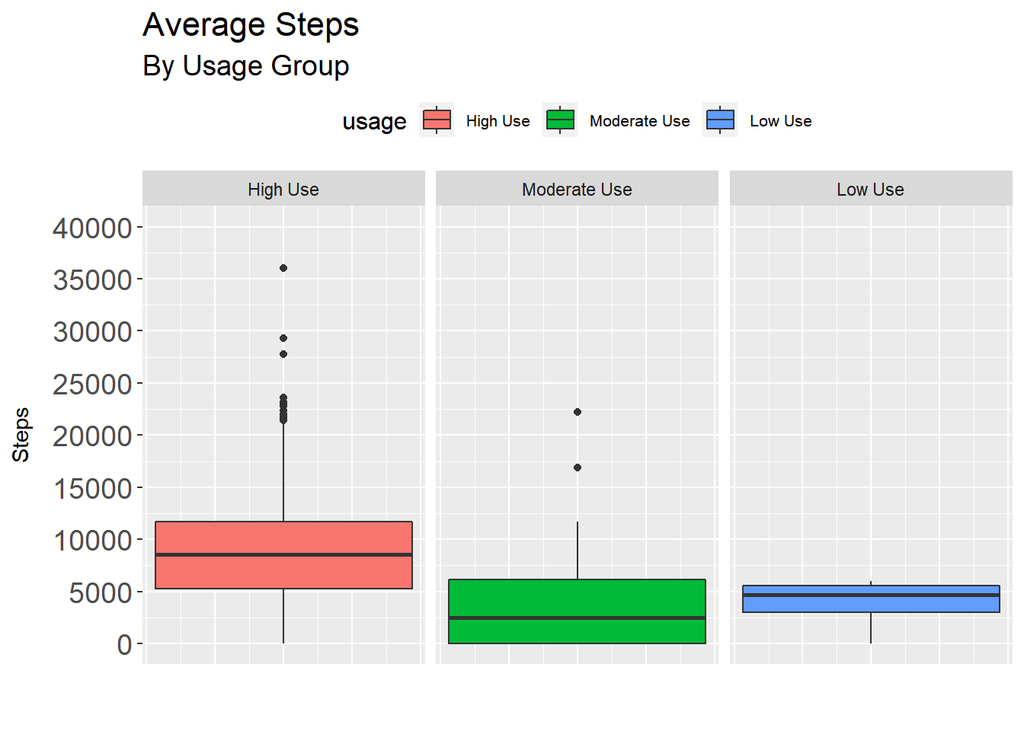

```r
ggplot(steps_by_ug, aes(x= , y=total_steps, fill=usage))+
  geom_boxplot()+
  scale_y_continuous(limits = c(0,40000), breaks = seq(0,40000, by =5000))+
  theme(legend.position = "none", plot.title = element_text(size = 11))+
  ggtitle("A boxplot with jitter")+
  xlab(" ")+
  labs(title = ("Average Steps"), subtitle = ('By Usage Group'), x=" ", y="Steps")+
  theme(plot.title=element_text(size = 16,hjust = 0))+
  theme(plot.subtitle=element_text(size = 14,hjust = 0))+
  theme(axis.text.y=element_text(size=14)) +
  theme(axis.text.x=element_text(size=14,hjust= 0.5))+
  theme(axis.title.x = element_text(margin = margin(t = 14, r = 0, b = 0, l = 0)))+
  theme(axis.title.y = element_text(margin = margin(t = 0, r = 10, b = 0, l = 0)))+
  theme(axis.text.x = element_blank(), axis.ticks.x = element_blank())+
  theme(legend.position = "top")+
  theme(legend.title=element_text(size=12))+
  theme(legend.text=element_text(size=8))+
  facet_grid(~usage)
```

```r
options(repr.plot.width = 5, repr.plot.height = 6)
```

### 5.3.3. Hourly steps through the day

```r
# Let's seperate the date_time colomn so we can work with the time colomn
hourly_steps<- hourly_steps%>%
  separate(date_time, into = c("date", "time"), sep= " ")%>%
  mutate(date= ymd(date))

head(hourly_steps,3)
```

```
## # A tibble: 3 × 4
##           id date       time     step_total
##        <dbl> <date>     <chr>         <dbl>
## 1 1503960366 2016-04-12 00:00:00        373
## 2 1503960366 2016-04-12 01:00:00        160
## 3 1503960366 2016-04-12 02:00:00        151
```

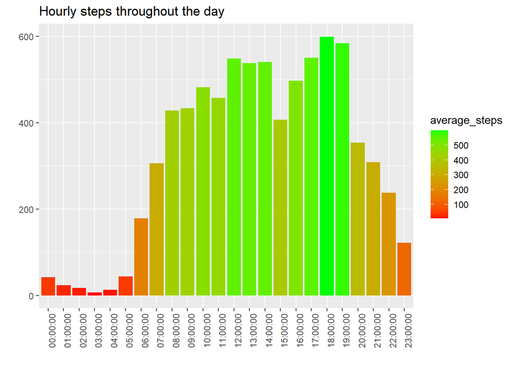

```r
hourly_steps%>%
  group_by(time)%>%
  summarise(average_steps = mean(step_total))%>%
  ggplot()+
geom_col(mapping = aes(x=time, y= average_steps, fill= average_steps))+
  labs(title = "Hourly steps throughout the day", x="", y="")+
  scale_fill_gradient(low = "red", high = "green")+
  theme(axis.text.x= element_text(angle = 90))
```

**Observations** * most active hours is between 8am to 7pm. * more steps are taken during lunch time (12pm-2pm) and evenings(5pm-7pm).

### 5.3.4. Daily use of smart device in minutes

WE want to know how long each user had their smart device on per day. To achieve this daily activity and daily usage group df will be merged

```r
daily_usage_group_merged<- merge(daily_activity,daily_usage_group, by = c("id"))

head(daily_usage_group_merged,3)
```

```
##           id       date total_steps total_distance tracker_distance
## 1 1503960366 2016-04-12       13162           8.50             8.50
## 2 1503960366 2016-04-13       10735           6.97             6.97
## 3 1503960366 2016-04-14       10460           6.74             6.74
##   logged_activities_distance very_active_distance moderately_active_distance
## 1                          0                 1.88                       0.55
## 2                          0                 1.57                       0.69
## 3                          0                 2.44                       0.40
##   light_active_distance sedentary_active_distance very_active_minutes
## 1                  6.06                         0                  25
## 2                  4.71                         0                  21
## 3                  3.91                         0                  30
##   fairly_active_minutes lightly_active_minutes sedentary_minutes calories
## 1                    13                    328               728     1985
## 2                    19                    217               776     1797
## 3                    11                    181              1218     1776
##   daysused    usage
## 1       30 High Use
## 2       30 High Use
## 3       30 High Use
```

There are 1440 minutes in a day, the sum of veryactiveminutes, fairlyactiveminutes, lightlyactiveminutes and sedentaryminutes is the total minutes the smart device was used by the user

```r
minutes_worn <- daily_usage_group_merged %>%
  mutate(total_minutes_worn = very_active_minutes+fairly_active_minutes+lightly_active_minutes+sedentary_minutes)%>%
  mutate (minutes_worn_percent = (total_minutes_worn/1440)*100) %>%
  mutate (worn = case_when(
    minutes_worn_percent == 100 ~ "All day",
    minutes_worn_percent < 100 & minutes_worn_percent >= 50~ "More than half day",
    minutes_worn_percent < 50 & minutes_worn_percent > 0 ~ "Less than half day"
  ))

head(minutes_worn,3)
```

```
##           id       date total_steps total_distance tracker_distance
## 1 1503960366 2016-04-12       13162           8.50             8.50
## 2 1503960366 2016-04-13       10735           6.97             6.97
## 3 1503960366 2016-04-14       10460           6.74             6.74
##   logged_activities_distance very_active_distance moderately_active_distance
## 1                          0                 1.88                       0.55
## 2                          0                 1.57                       0.69
## 3                          0                 2.44                       0.40
##   light_active_distance sedentary_active_distance very_active_minutes
## 1                  6.06                         0                  25
## 2                  4.71                         0                  21
## 3                  3.91                         0                  30
##   fairly_active_minutes lightly_active_minutes sedentary_minutes calories
## 1                    13                    328               728     1985
## 2                    19                    217               776     1797
## 3                    11                    181              1218     1776
##   daysused    usage total_minutes_worn minutes_worn_percent               worn
## 1       30 High Use               1094             75.97222 More than half day
## 2       30 High Use               1033             71.73611 More than half day
## 3       30 High Use               1440            100.00000            All day
```

To visualize on a pie chart for user type we create a dataframe to show the total users and will calculate percentage of minutes worn

```r
total_minutes_worn_percent<- minutes_worn%>%
  group_by(worn) %>%
  summarise(total = n()) %>%
  mutate(totals = sum(total)) %>%
  group_by(worn) %>%
  summarise(total_percent = total / totals) %>%
  mutate(labels = scales::percent(total_percent))

total_minutes_worn_percent$worn <- factor(total_minutes_worn_percent$worn, levels = c("All day", "More than half day", "Less than half day"))

head(total_minutes_worn_percent)
```

```
## # A tibble: 3 × 3
##   worn               total_percent labels
##   <fct>                      <dbl> <chr>
## 1 All day                   0.509  50.9%
## 2 Less than half day        0.0266 2.7%
## 3 More than half day        0.465  46.5%
```

lets us check how each of the usage group had their smart device on per day, to do this we create a dataframe for each of the usage group

```r
minutes_worn_high_use <- minutes_worn%>%
  filter (usage == "High Use")%>%
  group_by(worn) %>%
  summarise(total = n()) %>%
  mutate(totals = sum(total)) %>%
  group_by(worn) %>%
  summarise(total_percent = total / totals) %>%
  mutate(labels = scales::percent(total_percent))

minutes_worn_high_use$worn <- factor(minutes_worn_high_use$worn, levels = c("All day", "More than half day", "Less than half day"))


minutes_worn_moderate_use <- minutes_worn%>%
  filter(usage == "Moderate Use") %>%
  group_by(worn) %>%
  summarise(total = n()) %>%
  mutate(totals = sum(total)) %>%
  group_by(worn) %>%
  summarise(total_percent = total / totals) %>%
  mutate(labels = scales::percent(total_percent))

minutes_worn_moderate_use$worn <- factor(minutes_worn_moderate_use$worn, levels = c("All day", "More than half day", "Less than half day"))


minutes_worn_low_use <- minutes_worn%>%
  filter (usage == "Low Use") %>%
  group_by(worn) %>%
  summarise(total = n()) %>%
  mutate(totals = sum(total)) %>%
  group_by(worn) %>%
  summarise(total_percent = total / totals) %>%
  mutate(labels = scales::percent(total_percent))

minutes_worn_low_use$worn <- factor(minutes_worn_low_use$worn, levels = c("All day", "More than half day", "Less than half day"))


head(minutes_worn_high_use)
```

```
## # A tibble: 3 × 3
##   worn               total_percent labels
##   <fct>                      <dbl> <chr>
## 1 All day                   0.458  45.8%
## 2 Less than half day        0.0246 2.5%
## 3 More than half day        0.517  51.7%
```

```r
head(minutes_worn_moderate_use)
```

```
## # A tibble: 3 × 3
##   worn               total_percent labels
##   <fct>                      <dbl> <chr>
## 1 All day                   0.683  68%
## 2 Less than half day        0.0341 3%
## 3 More than half day        0.283  28%
```

```r
head(minutes_worn_low_use)
```

```
## # A tibble: 2 × 3
##   worn               total_percent labels
##   <fct>                      <dbl> <chr>
## 1 All day                     0.75 75%
## 2 More than half day          0.25 25%
```

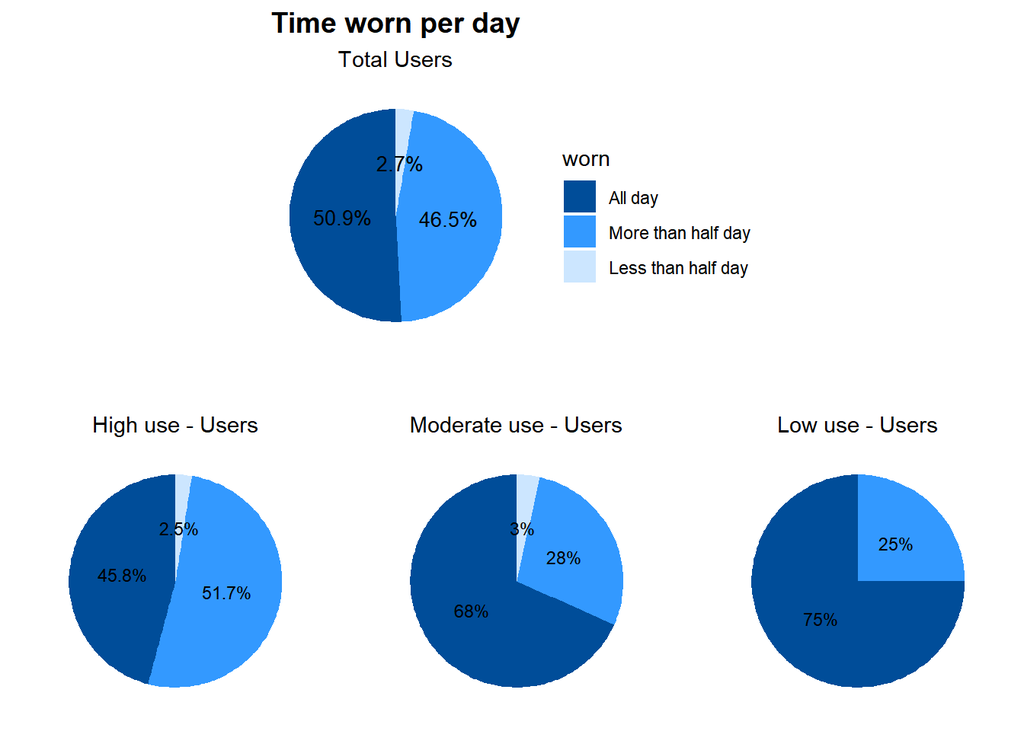

```r
ggarrange(
  ggplot(total_minutes_worn_percent, aes(x="",y=total_percent, fill=worn)) +
  geom_bar(stat = "identity", width = 1)+
  coord_polar("y", start=0)+
  theme_minimal()+
  theme(axis.title.x= element_blank(),
        axis.title.y = element_blank(),
        panel.border = element_blank(),
        panel.grid = element_blank(),
        axis.ticks = element_blank(),
        axis.text.x = element_blank(),
        plot.title = element_text(hjust = 0.5, size=14, face = "bold"),
        plot.subtitle = element_text(hjust = 0.5)) +
  scale_fill_manual(values = c("#004d99", "#3399ff", "#cce6ff"))+
  geom_text(aes(label = labels),
            position = position_stack(vjust = 0.5), size = 3.5)+
  labs(title="Time worn per day", subtitle = "Total Users"),
ggarrange(
    ggplot(minutes_worn_high_use, aes(x="",y=total_percent, fill=worn)) +
      geom_bar(stat = "identity", width = 1)+
      coord_polar("y", start=0)+
      theme_minimal()+
      theme(axis.title.x= element_blank(),
            axis.title.y = element_blank(),
            panel.border = element_blank(),
            panel.grid = element_blank(),
            axis.ticks = element_blank(),
            axis.text.x = element_blank(),
            plot.title = element_text(hjust = 0.5, size=14, face = "bold"),
            plot.subtitle = element_text(hjust = 0.5),
            legend.position = "none")+
      scale_fill_manual(values = c("#004d99", "#3399ff", "#cce6ff"))+
      geom_text(aes(label = labels),
                      position = position_stack(vjust = 0.5), size = 3)+
      labs(title="", subtitle = "High use - Users"),

    ggplot(minutes_worn_moderate_use, aes(x="",y=total_percent, fill=worn)) +
      geom_bar(stat = "identity", width = 1)+
      coord_polar("y", start=0)+
      theme_minimal()+
      theme(axis.title.x= element_blank(),
            axis.title.y = element_blank(),
            panel.border = element_blank(),
            panel.grid = element_blank(),
            axis.ticks = element_blank(),
            axis.text.x = element_blank(),
            plot.title = element_text(hjust = 0.5, size=14, face = "bold"),
            plot.subtitle = element_text(hjust = 0.5),
            legend.position = "none") +
      scale_fill_manual(values = c("#004d99", "#3399ff", "#cce6ff"))+
      geom_text(aes(label = labels),
                position = position_stack(vjust = 0.5), size = 3)+
      labs(title="", subtitle = "Moderate use - Users"),

    ggplot(minutes_worn_low_use, aes(x="",y=total_percent, fill=worn)) +
      geom_bar(stat = "identity", width = 1)+
      coord_polar("y", start=0)+
      theme_minimal()+
      theme(axis.title.x= element_blank(),
            axis.title.y = element_blank(),
            panel.border = element_blank(),
            panel.grid = element_blank(),
            axis.ticks = element_blank(),
            axis.text.x = element_blank(),
            plot.title = element_text(hjust = 0.5, size=14, face = "bold"),
            plot.subtitle = element_text(hjust = 0.5),
            legend.position = "none") +
      scale_fill_manual(values = c("#004d99", "#3399ff", "#cce6ff"))+
      geom_text(aes(label = labels),
                position = position_stack(vjust = 0.5), size = 3)+
      labs(title="", subtitle = "Low use - Users"),
    ncol = 3),
  nrow = 2)
```

**Observations** Let’s reminder that: * High users- 45.8% of the users who used the devices for 21 to 31 days used their smart devices all day, 51.7% used it more than half a day. * moderate users- wear the device more on a daily basis * Low users- they mostly wear the device all day on the day they use it, the graph show that they do not wear the device less than half a day * we can see that about 50% of the total users wore the smart device all day, 47% more than half day and 3% less than half day

### 5.3.4. Correlation between daily steps and calories

[figure not shown]

```r
ggplot(data=daily_activity)+
  geom_smooth(mapping=aes(x= total_steps,y= calories))+
   geom_point(mapping=aes(x=   total_steps,y= calories))+
  labs(title = "Daily steps vs Calories", x= "calories",y= "total_steps")+
      theme(panel.background = element_blank(), plot.title = element_text(size = 14))
```

**Observations** * There is a positive correlation between the total steps and calories burnt. * The more steps taken the more calories are burnt

## 6. Recommendations

1. To enhance user experiences give real-time feedback to users - providing regular daily (even hourly) engagement with users so that they can make quick informed decisions to optimize their routine and through this product involvement increases.
2. Device’s Accuracy: Improving a product’s accuracy in measurement is crucial to any fitness device, such features as sensor, connectivity and charging. This will help prevent lost meaningful data.
3. Product design: modify smart device so it can be worn all day to fit activities without interfering, modifications such as water resistance, long lasting batteries and fashionable.
4. Further Research: Surveys to be sent out at intervals in order to gain a more in-depth knowledge of consumer behavior and preferences such as:
- Consumers’ primary interest to pick up a fitness-focused wearable device (e.g, preference of functions)?
- Is there an issue with the ease of use of the device? i.e, syncing, integrating, charging, comfortableness for the user to sleep on with